# Predicting Online Purchases

An e-commerce conversion analytics proposal

Angela Qian

2026-08-12

## The question is simple

> Which website visits are most likely to end in a purchase?

**Project goal:** build a classification model that helps an e-commerce team recognize high-conversion sessions and improve the customer journey.

## This approved dataset is ready for analysis

### Online Shoppers Purchasing Intention

- **Source:** UCI Machine Learning Repository
- **Subject area:** Business
- **Task:** Classification and clustering
- **Observations:** 12,330 website sessions
- **Predictors:** 17 browsing and visitor variables
- **Outcome:** Revenue, true or false
- **Missing values:** None
- **License:** CC BY 4.0

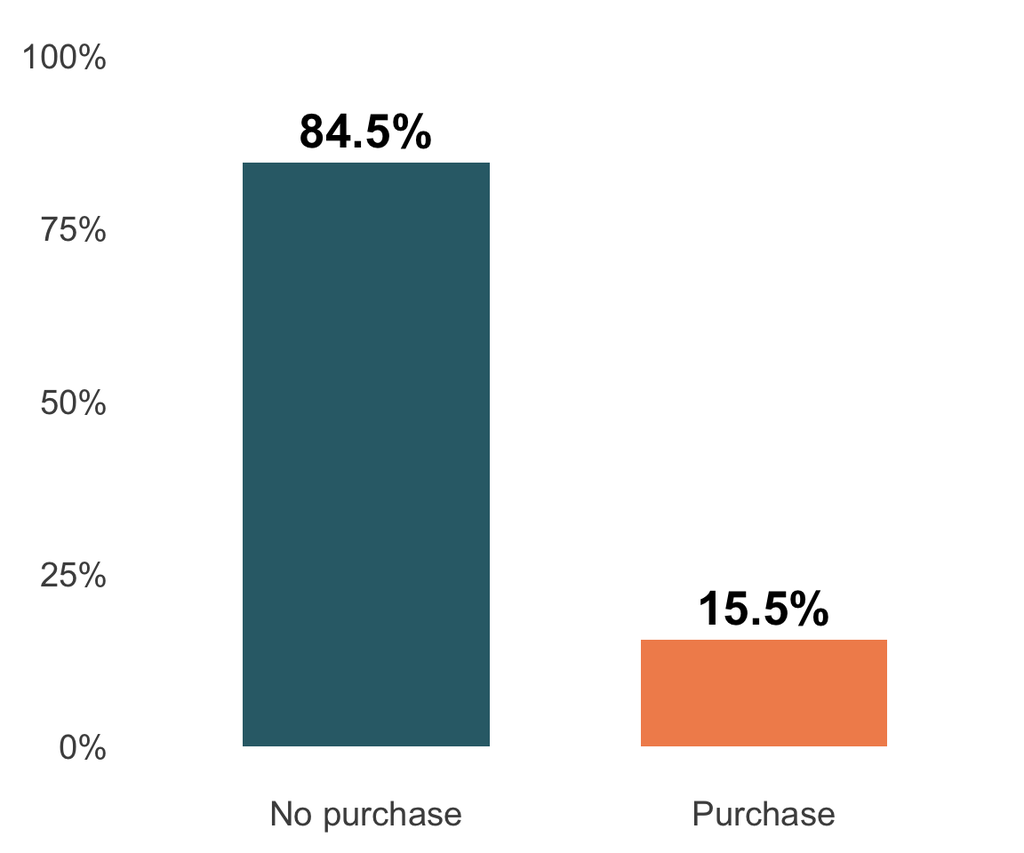

Figure 1: Observed session outcomes

## The variables describe a familiar shopping journey

### What visitors did

- Administrative pages and time
- Informational pages and time
- Product pages and time
- Bounce rate and exit rate
- Page value

### Who and when

- New or returning visitor
- Traffic type and region
- Browser and operating system
- Month and weekend
- Closeness to a special day

The target, **Revenue**, records whether the session ended in a transaction.

## The business problem is lost conversion opportunity

Most sessions do not end in a purchase. The e-commerce team needs to understand where purchasing behavior differs from non-purchasing behavior.

### Diagnose

Find behaviors connected with successful visits.

### Predict

Estimate the chance that a session will produce revenue.

### Improve

Use the findings to guide site and campaign decisions.

## The e-commerce manager is the main audience

The **E-commerce Marketing Manager** needs clear evidence about which sessions are more likely to convert and where customers may be dropping out.

The findings can also help:

- Website managers improve product-page journeys
- Paid media teams compare traffic quality
- CRM teams plan remarketing for visitors who do not purchase
- Executives monitor conversion opportunities

## Three questions keep the project focused

1. **Prediction:** How accurately can a purchase be predicted from session behavior?
2. **Drivers:** Which browsing and visitor variables are most useful for distinguishing purchases?
3. **Action:** Which customer journeys or traffic segments should receive attention first?

The outcome is binary, making logistic regression a clear baseline that is easy to explain.

## Purchasing sessions spend more time with products

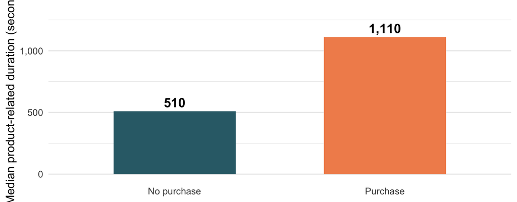

Figure 2: Median product-related duration by session outcome

Purchasing sessions spent about twice as long on product pages. This is a pattern, not proof of cause.

## Conversion changes across the year

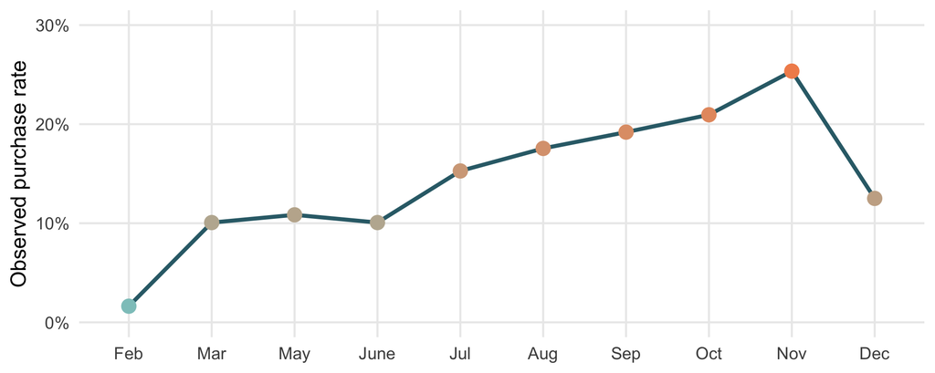

Figure 3: Observed purchase rate by month

November had the highest purchase rate (25.4%), so timing should be tested in the model.

## The analysis can stay practical and manageable

### Modeling steps

1. Check distributions and class balance
2. Create a stratified train/test split
3. Prepare categorical predictors
4. Fit logistic regression
5. Compare one tree-based model
6. Evaluate on the test set

### Evaluation measures

- **Recall:** purchases correctly identified
- **Precision:** how often a purchase prediction is right
- **ROC AUC:** overall ranking quality
- **Confusion matrix:** correct and incorrect decisions

Because only 15.5% of sessions purchased, accuracy alone will not be enough.

## The project can lead to clear marketing actions

If the model performs well, the company can:

- Identify the browsing patterns most connected with purchases
- Improve pages where visitors commonly exit
- Compare the quality of traffic sources
- Time campaigns around stronger conversion periods
- Build better remarketing audiences

**Recommendation:** approve the Online Shoppers dataset and begin with exploratory analysis and logistic regression.

## Approved source

**Dataset:** Online Shoppers Purchasing Intention Dataset  
https://archive.ics.uci.edu/dataset/468/online+shoppers+purchasing+intention+dataset

**DOI:** https://doi.org/10.24432/C5F88Q

**License:** Creative Commons Attribution 4.0 International

**Downloaded file:** `Online-Shoppers-UCI.csv`

This project offers a direct business question, understandable variables, and a simple outcome that is easy to present.